# Lab 7 Homework

Laurine Cabiling

2023-02-05

## Instructions

Answer the following questions and complete the exercises in RMarkdown. Please embed all of your code and push your final work to your repository. Your final lab report should be organized, clean, and run free from errors. Remember, you must remove the `#` for the included code chunks to run. Be sure to add your name to the author header above.

Make sure to use the formatting conventions of RMarkdown to make your report neat and clean!

## Load the libraries

```r
library(tidyverse)
library(janitor)
library(skimr)
```

```r
#install.packages("naniar")
library("naniar")
```

## Data

**1. For this homework, we will use two different data sets. Please load `amniota` and `amphibio`.**

`amniota` data:  
Myhrvold N, Baldridge E, Chan B, Sivam D, Freeman DL, Ernest SKM (2015). “An amniote life-history database to perform comparative analyses with birds, mammals, and reptiles.” *Ecology*, *96*, 3109. doi: 10.1890/15-0846.1 (URL: https://doi.org/10.1890/15-0846.1).

```r
amniota <- readr::read_csv("data/amniota.csv")
```

`amphibio` data:  
Oliveira BF, São-Pedro VA, Santos-Barrera G, Penone C, Costa GC (2017). “AmphiBIO, a global database for amphibian ecological traits.” *Scientific Data*, *4*, 170123. doi: 10.1038/sdata.2017.123 (URL: https://doi.org/10.1038/sdata.2017.123).

```r
amphibio <- readr::read_csv("data/amphibio.csv")
```

## Questions

**2. Do some exploratory analysis of the `amniota` data set. Use the function(s) of your choice. Try to get an idea of how NA’s are represented in the data.**

```r
glimpse(amniota)
```

```
## Rows: 21,322
## Columns: 36
## $ class                                 <chr> "Aves", "Aves", "Aves", "Aves", …
## $ order                                 <chr> "Accipitriformes", "Accipitrifor…
## $ family                                <chr> "Accipitridae", "Accipitridae", …
## $ genus                                 <chr> "Accipiter", "Accipiter", "Accip…
## $ species                               <chr> "albogularis", "badius", "bicolo…
## $ subspecies                            <dbl> -999, -999, -999, -999, -999, -9…
## $ common_name                           <chr> "Pied Goshawk", "Shikra", "Bicol…
## $ female_maturity_d                     <dbl> -999.000, 363.468, -999.000, -99…
## $ litter_or_clutch_size_n               <dbl> -999.000, 3.250, 2.700, -999.000…
## $ litters_or_clutches_per_y             <dbl> -999, 1, -999, -999, 1, -999, -9…
## $ adult_body_mass_g                     <dbl> 251.500, 140.000, 345.000, 142.0…
## $ maximum_longevity_y                   <dbl> -999.00000, -999.00000, -999.000…
## $ gestation_d                           <dbl> -999, -999, -999, -999, -999, -9…
```

[output cut: 23 more lines]

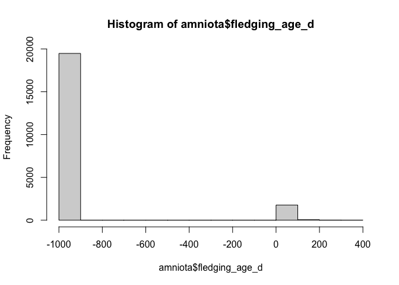

```r
hist(amniota$fledging_age_d)
```

**3. Do some exploratory analysis of the `amphibio` data set. Use the function(s) of your choice. Try to get an idea of how NA’s are represented in the data.** The NA’s are represented as NA’s.

```r
glimpse(amphibio)
```

```
## Rows: 6,776
## Columns: 38
## $ id                      <chr> "Anf0001", "Anf0002", "Anf0003", "Anf0004", "A…
## $ Order                   <chr> "Anura", "Anura", "Anura", "Anura", "Anura", "…
## $ Family                  <chr> "Allophrynidae", "Alytidae", "Alytidae", "Alyt…
## $ Genus                   <chr> "Allophryne", "Alytes", "Alytes", "Alytes", "A…
## $ Species                 <chr> "Allophryne ruthveni", "Alytes cisternasii", "…
## $ Fos                     <dbl> NA, NA, NA, NA, NA, 1, 1, 1, 1, 1, 1, 1, 1, NA…
## $ Ter                     <dbl> 1, 1, 1, 1, 1, 1, 1, 1, 1, 1, 1, 1, 1, 1, 1, 1…
## $ Aqu                     <dbl> 1, 1, 1, 1, NA, 1, 1, 1, 1, 1, 1, 1, 1, 1, 1, …
## $ Arb                     <dbl> 1, 1, 1, 1, 1, 1, NA, NA, NA, NA, NA, NA, NA, …
## $ Leaves                  <dbl> NA, NA, NA, NA, NA, NA, NA, NA, NA, NA, NA, NA…
## $ Flowers                 <dbl> NA, NA, NA, NA, NA, NA, NA, NA, NA, NA, NA, NA…
## $ Seeds                   <dbl> NA, NA, NA, NA, NA, NA, NA, NA, NA, NA, NA, NA…
## $ Fruits                  <lgl> NA, NA, NA, NA, NA, NA, NA, NA, NA, NA, NA, NA…
```

[output cut: 25 more lines]

```r
anyNA(amphibio)
```

```
## [1] TRUE
```

**4. How many total NA’s are in each data set? Do these values make sense? Are NA’s represented by values?**

`amniota`  
The NA’s are represented as -999 values in this dataframe.

```r
amniota %>%
 summarise_all(~(sum(is.na(.))))
```

```
## # A tibble: 1 × 36
##   class order family genus species subspecies common_n…¹ femal…² litte…³ litte…⁴
##   <int> <int>  <int> <int>   <int>      <int>      <int>   <int>   <int>   <int>
## 1     0     0      0     0       0          0          0       0       0       0
## # … with 26 more variables: adult_body_mass_g <int>, maximum_longevity_y <int>,
## #   gestation_d <int>, weaning_d <int>, birth_or_hatching_weight_g <int>,
## #   weaning_weight_g <int>, egg_mass_g <int>, incubation_d <int>,
## #   fledging_age_d <int>, longevity_y <int>, male_maturity_d <int>,
## #   inter_litter_or_interbirth_interval_y <int>, female_body_mass_g <int>,
## #   male_body_mass_g <int>, no_sex_body_mass_g <int>, egg_width_mm <int>,
## #   egg_length_mm <int>, fledging_mass_g <int>, adult_svl_cm <int>, …
```

```r
amniota %>%
  count("-999")
```

```
## # A tibble: 1 × 2
##   `"-999"`     n
##   <chr>    <int>
## 1 -999     21322
```

`amphibio`  
The NA’s appear as NA’s in the dataframe

```r
amphibio %>%
  summarise_all(~(sum(is.na(.))))
```

```
## # A tibble: 1 × 38
##      id Order Family Genus Species   Fos   Ter   Aqu   Arb Leaves Flowers Seeds
##   <int> <int>  <int> <int>   <int> <int> <int> <int> <int>  <int>   <int> <int>
## 1     0     0      0     0       0  6053  1104  2810  4347   6752    6772  6772
## # … with 26 more variables: Fruits <int>, Arthro <int>, Vert <int>, Diu <int>,
## #   Noc <int>, Crepu <int>, Wet_warm <int>, Wet_cold <int>, Dry_warm <int>,
## #   Dry_cold <int>, Body_mass_g <int>, Age_at_maturity_min_y <int>,
## #   Age_at_maturity_max_y <int>, Body_size_mm <int>,
## #   Size_at_maturity_min_mm <int>, Size_at_maturity_max_mm <int>,
## #   Longevity_max_y <int>, Litter_size_min_n <int>, Litter_size_max_n <int>,
## #   Reproductive_output_y <int>, Offspring_size_min_mm <int>, …
```

**5. Make any necessary replacements in the data such that all NA’s appear as “NA”.**

```r
amniota <- amniota %>%
  na_if("-999")
```

**6. Use the package `naniar` to produce a summary, including percentages, of missing data in each column for the `amniota` data.**

```r
naniar::miss_var_summary(amniota)
```

```
## # A tibble: 36 × 3
##    variable                       n_miss pct_miss
##    <chr>                           <int>    <dbl>
##  1 subspecies                      21322    100
##  2 female_body_mass_at_maturity_g  21318    100.
##  3 female_svl_at_maturity_cm       21120     99.1
##  4 fledging_mass_g                 21111     99.0
##  5 male_svl_cm                     21040     98.7
##  6 no_sex_maturity_d               20860     97.8
##  7 egg_width_mm                    20727     97.2
##  8 egg_length_mm                   20702     97.1
##  9 weaning_weight_g                20258     95.0
## 10 female_svl_cm                   20242     94.9
## # … with 26 more rows
```

**7. Use the package `naniar` to produce a summary, including percentages, of missing data in each column for the `amphibio` data.**

```r
naniar::miss_var_summary(amphibio)
```

```
## # A tibble: 38 × 3
##    variable n_miss pct_miss
##    <chr>     <int>    <dbl>
##  1 Fruits     6774    100.
##  2 Flowers    6772     99.9
##  3 Seeds      6772     99.9
##  4 Leaves     6752     99.6
##  5 Dry_cold   6735     99.4
##  6 Vert       6657     98.2
##  7 OBS        6651     98.2
##  8 Wet_cold   6625     97.8
##  9 Crepu      6608     97.5
## 10 Dry_warm   6572     97.0
## # … with 28 more rows
```

**8. For the `amniota` data, calculate the number of NAs in the `egg_mass_g` column sorted by taxonomic class; i.e. how many NA’s are present in the `egg_mass_g` column in birds, mammals, and reptiles? Does this results make sense biologically? How do these results affect your interpretation of NA’s?**

```r
names(amniota)
```

```
##  [1] "class"
##  [2] "order"
##  [3] "family"
##  [4] "genus"
##  [5] "species"
##  [6] "subspecies"
##  [7] "common_name"
##  [8] "female_maturity_d"
##  [9] "litter_or_clutch_size_n"
## [10] "litters_or_clutches_per_y"
## [11] "adult_body_mass_g"
## [12] "maximum_longevity_y"
## [13] "gestation_d"
## [14] "weaning_d"
## [15] "birth_or_hatching_weight_g"
```

[output cut: 21 more lines]

```r
amniota %>%
  group_by(class) %>%
  summarize(total_NA = sum(is.na(egg_mass_g)))
```

```
## # A tibble: 3 × 2
##   class    total_NA
##   <chr>       <int>
## 1 Aves         4914
## 2 Mammalia     4953
## 3 Reptilia     6040
```

```r
amniota %>%
 summarise_all(~(sum(is.na(.))))
```

```
## # A tibble: 1 × 36
##   class order family genus species subspecies common_n…¹ femal…² litte…³ litte…⁴
##   <int> <int>  <int> <int>   <int>      <int>      <int>   <int>   <int>   <int>
## 1     0     0      0     0       0      21322       1641   17849    8244   16374
## # … with 26 more variables: adult_body_mass_g <int>, maximum_longevity_y <int>,
## #   gestation_d <int>, weaning_d <int>, birth_or_hatching_weight_g <int>,
## #   weaning_weight_g <int>, egg_mass_g <int>, incubation_d <int>,
## #   fledging_age_d <int>, longevity_y <int>, male_maturity_d <int>,
## #   inter_litter_or_interbirth_interval_y <int>, female_body_mass_g <int>,
## #   male_body_mass_g <int>, no_sex_body_mass_g <int>, egg_width_mm <int>,
## #   egg_length_mm <int>, fledging_mass_g <int>, adult_svl_cm <int>, …
```

```r
amniota %>%
  group_by(class) %>%
  summarize(total=n())
```

```
## # A tibble: 3 × 2
##   class    total
##   <chr>    <int>
## 1 Aves      9802
## 2 Mammalia  4953
## 3 Reptilia  6567
```

To ensure I got the right number of individual species were missing an egg_mass_g value, I summarized all of the missing NA’s. Then to see if the results made biological sense, I summarized the total number of individuals within each class. The values make sense almost all of Mammalia do not lay eggs, so it makes sense the entire class is missing an egg weight value. Furthermore, we know reptiles and birds do lay eggs, but not all of the species were able to get an egg weight for some reason. Therefore, we can be missing important data as the mass of the egg can indicate possible future health risks for the off springs as it can be an indication that there is a decrease in nutrients within their habitat.

**9. The `amphibio` data have variables that classify species as fossorial (burrowing), terrestrial, aquatic, or arboreal.Calculate the number of NA’s in each of these variables. Do you think that the authors intend us to think that there are NA’s in these columns or could they represent something else? Explain.**

```r
names(amphibio)
```

```
##  [1] "id"                      "Order"
##  [3] "Family"                  "Genus"
##  [5] "Species"                 "Fos"
##  [7] "Ter"                     "Aqu"
##  [9] "Arb"                     "Leaves"
## [11] "Flowers"                 "Seeds"
## [13] "Fruits"                  "Arthro"
## [15] "Vert"                    "Diu"
## [17] "Noc"                     "Crepu"
## [19] "Wet_warm"                "Wet_cold"
## [21] "Dry_warm"                "Dry_cold"
## [23] "Body_mass_g"             "Age_at_maturity_min_y"
## [25] "Age_at_maturity_max_y"   "Body_size_mm"
## [27] "Size_at_maturity_min_mm" "Size_at_maturity_max_mm"
## [29] "Longevity_max_y"         "Litter_size_min_n"
## [31] "Litter_size_max_n"       "Reproductive_output_y"
## [33] "Offspring_size_min_mm"   "Offspring_size_max_mm"
## [35] "Dir"                     "Lar"
## [37] "Viv"                     "OBS"
```

```r
amphibio %>%
  select(Fos, Ter, Aqu, Arb) %>%
  summarize_all((~(sum(is.na(.)))))
```

```
## # A tibble: 1 × 4
##     Fos   Ter   Aqu   Arb
##   <int> <int> <int> <int>
## 1  6053  1104  2810  4347
```

```r
amphibio %>%
  select(Species, Fos, Ter, Aqu, Arb)
```

```
## # A tibble: 6,776 × 5
##    Species                    Fos   Ter   Aqu   Arb
##    <chr>                    <dbl> <dbl> <dbl> <dbl>
##  1 Allophryne ruthveni         NA     1     1     1
##  2 Alytes cisternasii          NA     1     1     1
##  3 Alytes dickhilleni          NA     1     1     1
##  4 Alytes maurus               NA     1     1     1
##  5 Alytes muletensis           NA     1    NA     1
##  6 Alytes obstetricans          1     1     1     1
##  7 Discoglossus galganoi        1     1     1    NA
##  8 Discoglossus jeanneae        1     1     1    NA
##  9 Discoglossus montalentii     1     1     1    NA
## 10 Discoglossus nigriventer     1     1     1    NA
## # … with 6,766 more rows
```

I think the authors did mean to put NA’s in the values to indicate that the species was never documented or found in that specific habitat. It could be like a binary code where 1 is yes, they are found there, and NA instad of 0 to mean no they were not found there.

**10. Now that we know how NA’s are represented in the `amniota` data, how would you load the data such that the values which represent NA’s are automatically converted?**

```r
amniota <- readr::read_csv("data/amniota.csv") %>%
  na_if("-999")
```

## Push your final code to GitHub!

Please be sure that you check the `keep md` file in the knit preferences.